# Workshops

We run 4 workshop series with the support of the data consultants. Each series consists of several workshops over the term, offered on a weekly basis. Students can enroll in any or all of the series’ listings.

We also encourage students to sign up for complementary workshops when possible. To this end, 6 students registered for both Learning R and Statistical Fundamentals, 11 for Statistical Fundamentals and Fitting Models, 4 for Learning R and Fitting Models, and 3 for all 3 series.

The series on Bayesian statistics was developed this academic year. This is being run as both an intro and advanced workshop, only the former of which has been delivered at the time of writing this report.

Learning R was offered in W1, the remaining workshops were offered in W2.

## Feedback

- “The sessions were well run and were very helpful!”

The most useful thing from the workshop was…

- “Overall very useful!”
- “[D]ata learning in parallel with R learning”
- “Helping me to learn how to manage my data”
- “Since i am intersted in data scine field, it helps me to gain the insights about the R programming.”
- “Providing multiple ways to carry out a function in R. It was great to have options for what makes the most sense for the individual. Also, the meaning/purpose of each line of code was clearly explained.”

## Series Summary

### Non unique attendance

This represents overall, ie, non unique, attendence over each series.

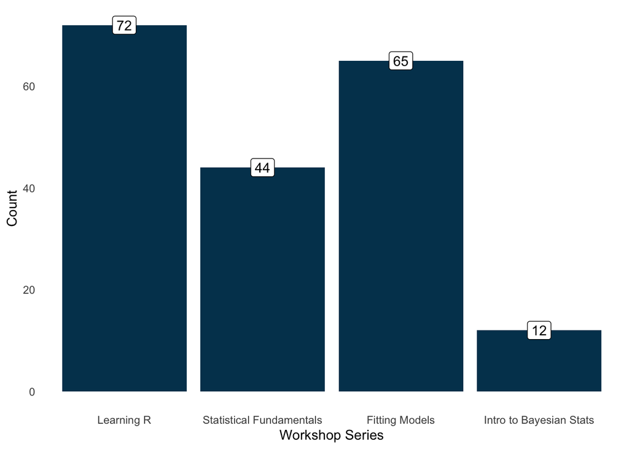

### Unique attendees

Reflects unique attendees per workshop series. Attendees may be repeated across workshop series. This data is tallied manually and at time of writing this report does not include the Intro to Bayesian Stats workshop.

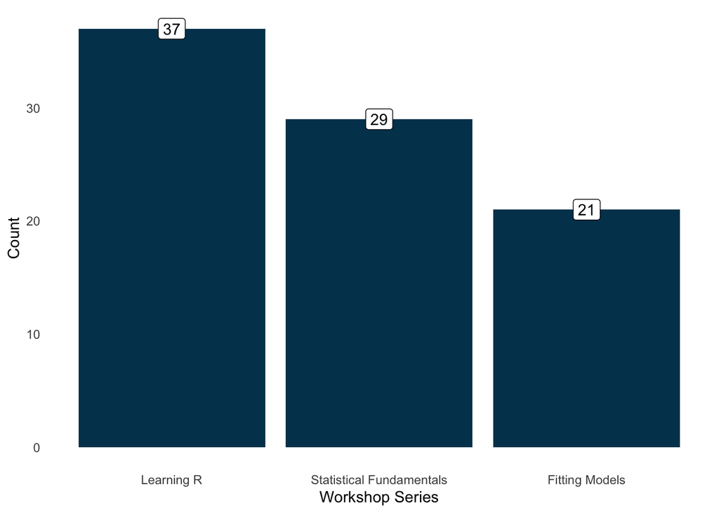

#### By Discipline & Series

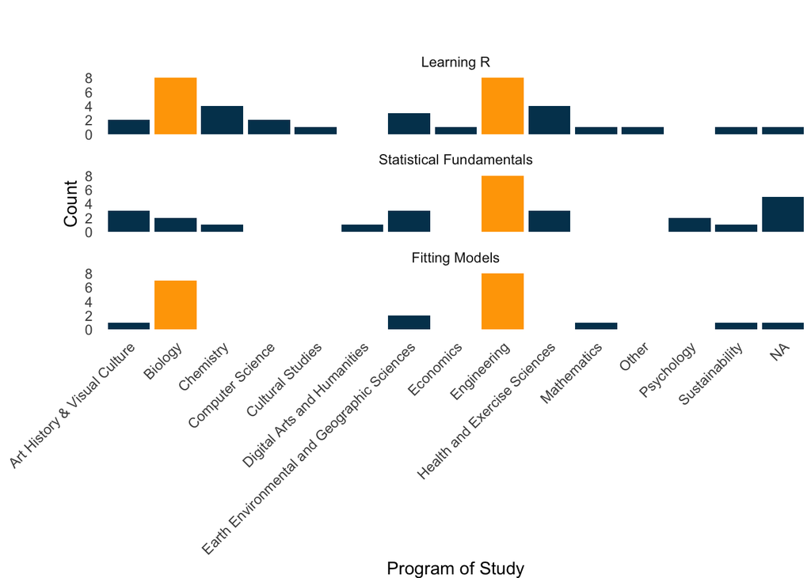

#### By Academic Role & Series

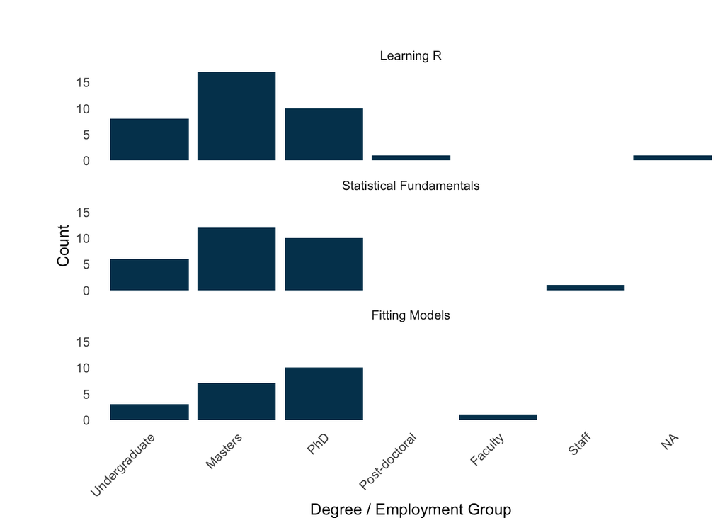

## Series Summary Tables

### Learning R

Offered in W1, 37 unique registrants.

| Workshop | Attendance |
| --- | --- |
| Learning R: Fundamental Concepts with R Studios | 12 |
| Learning R: Importing Data | 10 |
| Learning R: Exploring Data | 20 |
| Learning R: Subsetting and Filtering Data | 10 |
| Learning R: Iterating Over Data | 7 |
| Learning R: Conditions | 10 |
| Learning R: Data Visualization | 3 |

### Statistical Fundamentals

Offered in W2, 29 unique users

| Workshop | Attendance |
| --- | --- |
| Statistical Fundamentals: A Visual Approach - Population, Sampling, Sampling Distribution and Central Limit Theorem | 12 |
| Statistical Fundamentals: A Visual Approach - Visualizing Errors and Common Pitfalls | 7 |
| Statistical Fundamentals: A Visual Approach - P value, Significance and T-test | 7 |
| Statistical Fundamentals: A Visual Approach - Visualizing Samples with Boxplots: Kick the Bar Chart Habit | 7 |
| Statistical Fundamentals: A Visual Approach - All About T-tests and Visualizations | 6 |
| Statistical Fundamentals: A Visual Approach - Non-parametric Tests and Visualizations | 5 |

### Fitting Models

| Workshop | Attendance |
| --- | --- |
| Fitting Model to Data Not Data to Models: Simple Linear Regression | 13 |
| Fitting Model to Data Not Data to Models: Fitting Linear Models in ‘R’ | 10 |
| Fitting Model to Data Not Data to Models: Multiple Linear Regression in ‘R’ | 8 |
| Fitting Model to Data Not Data to Models: Interaction Terms and Hierarchical Linear Models/Linear Mixed Models | 9 |
| Fitting Model to Data Not Data to Models: (Hierarchical) Generalized Linear Models | 7 |
| Fitting Model to Data Not Data to Models: Generalized Additive Models | 10 |
| Fitting Model to Data Not Data to Models: Interpreting and Predicting from Generalized Additive Models | 8 |

### Bayesian Statistics

Offered in W2

| Workshop | Attendance |
| --- | --- |
| Intro to Bayesian Stats | 12 |